# PS-2 - SAHIL AGGARWAL

Collaborators - Shreya Sabharwal

### Question 1.1

[figure not shown]

Yes we moved closer to the maxima

##### Question 2

```python
import numpy as np
import matplotlib.pyplot as plt
%matplotlib inline
```

```python
def f(x):
    return -(x*x)

def gradient(x):
    return (-2)*x
```

```python
import time
def one_d_gradient_ascent(x0,maxIter,R,epsilon=0.0001):
    i=0
    while i<maxIter:
        print ("x value:",x0)
        print ("Function value:", f(x0))
        print ("Gradient of the function", gradient(x0),'\n')
        x1 = x0 + (R*gradient(x0))
        if(abs(x1-x0) <=epsilon):
            break
        x0 = x1
        i=i+1
    print("Iterations:", i)
    print("Maxima", x1)
```

```python
one_d_gradient_ascent(4,1000,0.1)
```

```
x value: 4
Function value: -16
Gradient of the function -8

x value: 3.2
Function value: -10.240000000000002
Gradient of the function -6.4

x value: 2.56
Function value: -6.5536
Gradient of the function -5.12

x value: 2.048
Function value: -4.194304
Gradient of the function -4.096

x value: 1.6384
Function value: -2.68435456
Gradient of the function -3.2768

x value: 1.31072
Function value: -1.7179869184000003
Gradient of the function -2.62144

x value: 1.0485760000000002
Function value: -1.0995116277760004
Gradient of the function -2.0971520000000003

x value: 0.8388608000000002
Function value: -0.7036874417766403
Gradient of the function -1.6777216000000004

x value: 0.6710886400000001
Function value: -0.45035996273704976
Gradient of the function -1.3421772800000003

x value: 0.5368709120000001
Function value: -0.2882303761517119
Gradient of the function -1.0737418240000003

```

[output cut: 115 more lines]

```

x value: 0.0006646139978924582
Function value: -4.4171176619459645e-07
Gradient of the function -0.0013292279957849164

x value: 0.0005316911983139665
Function value: -2.826955303645417e-07
Gradient of the function -0.001063382396627933

x value: 0.00042535295865117324
Function value: -1.809251394333067e-07
Gradient of the function -0.0008507059173023465

Iterations: 41
Maxima 0.0003402823669209386
```

##### Question 3

```python
one_d_gradient_ascent(3,800,0.1)
```

```
x value: 3
Function value: -9
Gradient of the function -6

x value: 2.4
Function value: -5.76
Gradient of the function -4.8

x value: 1.92
Function value: -3.6864
Gradient of the function -3.84

x value: 1.536
Function value: -2.359296
Gradient of the function -3.072

x value: 1.2288000000000001
Function value: -1.5099494400000002
Gradient of the function -2.4576000000000002

x value: 0.9830400000000001
Function value: -0.9663676416000002
Gradient of the function -1.9660800000000003

x value: 0.7864320000000001
Function value: -0.6184752906240002
Gradient of the function -1.5728640000000003

x value: 0.6291456000000001
Function value: -0.3958241859993601
Gradient of the function -1.2582912000000002

x value: 0.5033164800000001
Function value: -0.25332747903959046
Gradient of the function -1.0066329600000001

x value: 0.40265318400000005
Function value: -0.1621295865853379
Gradient of the function -0.8053063680000001

```

[output cut: 107 more lines]

```

x value: 0.0007788445287802246
Function value: -6.0659880001089e-07
Gradient of the function -0.0015576890575604492

x value: 0.0006230756230241796
Function value: -3.882232320069696e-07
Gradient of the function -0.0012461512460483592

x value: 0.0004984604984193437
Function value: -2.4846286848446056e-07
Gradient of the function -0.0009969209968386874

Iterations: 39
Maxima 0.00039876839873547495
```

##### Question 4

[figure not shown]

##### Question 5

[figure not shown]

##### Question 6

[figure not shown]

##### Question 7

```python
def f(x, A):
    return (-1)*x.T @ A @ x

def gradient(x, A):
    return (-1)*(A + A.T) @ x
```

```python
def two_d_gradient_ascent(x0, A, R, max_iterations, mat_x, e=0.00001):
    start_time = time.time()
    for i in range(max_iterations):
        x1 = x0 + (R*gradient(x0, A))
        mat_x = np.vstack((mat_x, x1.T))
        if((x1-x0).any() <=e):
            break
        x0 = x1
    print("\nConverged Iterations:", i)
    print("\nMaximum of the function:", x1)
    print("\nTime taken:", time.time() - start_time)
    print("\nAll values of x:", mat_x)
    return mat_x
```

```python
x = np.matrix("2;-3")
print(x)
```

```
[[ 2]
 [-3]]
```

```python
A = np.matrix("1,2; 2,8")
print(A)
```

```
[[1 2]
 [2 8]]
```

```python
mat_x =  two_d_gradient_ascent(x, A, 0.1, 10000, mat_x=x.T)
```

```
Converged Iterations: 7555

Maximum of the function: [[ 2.e-323]
 [-5.e-324]]

Time taken: 0.7289009094238281

All values of x: [[ 2.00e+000 -3.00e+000]
 [ 2.80e+000  1.00e+000]
 [ 1.84e+000 -1.72e+000]
 ...
 [ 2.47e-323 -4.94e-324]
 [ 1.98e-323 -4.94e-324]
 [ 1.98e-323 -4.94e-324]]
```

```python
mat_x_2 = two_d_gradient_ascent(x, A, 0.11, 10000, mat_x=x.T)
```

```
Converged Iterations: 6833

Maximum of the function: [[ 2.e-323]
 [-5.e-324]]

Time taken: 0.3630819320678711

All values of x: [[ 2.0000e+000 -3.0000e+000]
 [ 2.8800e+000  1.4000e+000]
 [ 1.6304e+000 -2.3312e+000]
 ...
 [ 2.4703e-323 -4.9407e-324]
 [ 1.9763e-323 -4.9407e-324]
 [ 1.9763e-323 -4.9407e-324]]
```

For the same value of x and different values of learning rate,the number of iterations and the time taken to converge is more for smaller learning rate.

##### Question 8

```python
def gradient_ascent_contour(mat_x, A, max_iterations,lev,p1=6,p2=6):
    n = 30
    ex1 = np.linspace(-p1, p2, num=n)
    ex2 = np.linspace(-p1, p2, num=n)
    grid1, grid2 = np.meshgrid(ex1, ex2)
    ## fill the grid via looping.  You may prefer to use ufuncs instead.
    z = np.empty_like(grid1)
    for i in range(z.shape[0]):
        for j in range(z.shape[1]):
            x = np.array([grid1[i,j], grid2[i,j]])
            z[i,j] = f(x,A)
    plt.figure(figsize=(12,12))
    p = plt.contour(grid1, grid2, z,levels = lev,
                    colors = 'black')
    plt.clabel(p, inline=1, fontsize=10)
    mat_x = np.array(mat_x)
    for i in range(100):
        plt.scatter(mat_x[i][0],mat_x[i][1], c='red', s=50)
        if(i>0):
            plt.plot([mat_x[i][0],mat_x[i-1][0]],[mat_x[i][1],mat_x[i-1][1]], c='red')
    plt.scatter(mat_x[-1][0],mat_x[-1][1], c='blue', s=50)
    plt.show()
```

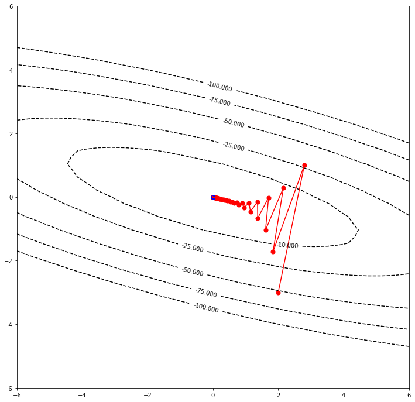

```python
lev = [-100,-75, -50,-25,-10,0,10,25,50,75,100]
gradient_ascent_contour(mat_x, A, 10000,lev)
```

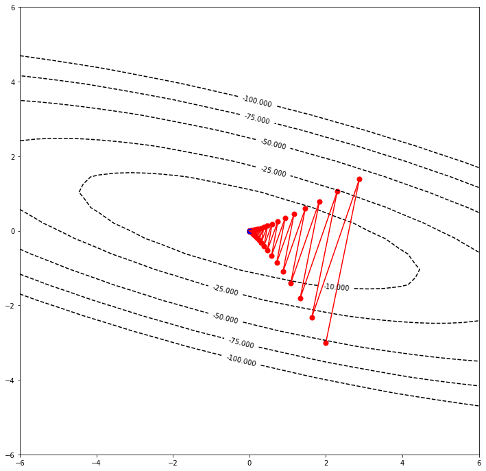

```python
gradient_ascent_contour(mat_x_2, A, 10000,lev)
```

The factor by which the value of x decreases becomes smaller. The difference between the points that are near the origin cannot be clearly seen as these points are very close. They achieve convergence at the origin. The blue point at the origin is the last point.

##### Question 9

```python
x_points = np.matrix("10; 20; 30; 40; 50")
A_mat_5d = np.matrix(np.arange(1,26).reshape(5,5))
I5 = np.eye(A_mat_5d.shape[0])
```

```python
print(A_mat_5d)
```

```
[[ 1  2  3  4  5]
 [ 6  7  8  9 10]
 [11 12 13 14 15]
 [16 17 18 19 20]
 [21 22 23 24 25]]
```

```python
A_mat_5d = (A_mat_5d + A_mat_5d.T)/2 + 10*I5
matrix_x = two_d_gradient_ascent(x_points, A_mat_5d, 0.01, 10000, mat_x=x_points.T)
```

```
Converged Iterations: 9716

Maximum of the function: [[-3.0e-323]
 [-1.5e-323]
 [-4.9e-324]
 [ 4.9e-324]
 [ 2.0e-323]]

Time taken: 0.7882719039916992

All values of x: [[ 1.00e+001  2.00e+001  3.00e+001  4.00e+001  5.00e+001]
 [-1.90e+001 -2.00e+001 -2.10e+001 -2.20e+001 -2.30e+001]
 [ 1.00e-001  5.60e+000  1.11e+001  1.66e+001  2.21e+001]
 ...
 [-3.46e-323 -1.98e-323 -4.94e-324  4.94e-324  1.98e-323]
 [-2.96e-323 -1.48e-323 -4.94e-324  4.94e-324  1.98e-323]
 [-2.96e-323 -1.48e-323 -4.94e-324  4.94e-324  1.98e-323]]
```

Convergs at R= 0.01. For the same learning rate, the more the number of dimensions, the more time it takes to converge.

##### Question 10

```python
value = np.linalg.eigvals(A_mat_5d)
condition_number = np.sqrt(np.max(abs(value))/np.min(abs(value)))
print(condition_number)
```

```
4.694460254014033
```

[figure not shown]

##### Question 11

```python
A = np.matrix([[1,1],[1,1]])
np.linalg.det(A)
```

```
0.0
```

```python
np.linalg.eigvals(A)
```

```
array([2., 0.])
```

```python
np.linalg.cond(A)
```

```
5.961777047638983e+16
```

```python
notebook_example = np.matrix([[1,2],[2,8]])
print(notebook_example)
```

```
[[1 2]
 [2 8]]
```

```python
np.linalg.det(notebook_example)
```

```
4.0
```

```python
np.linalg.eigvals(notebook_example)
```

```
array([0.46887113, 8.53112887])
```

```python
np.linalg.cond(notebook_example)
```

```
18.195039966835857
```

##### Question12

```python
def q12(A, alpha, R, eps, lev,p1=5, p2=5):
    print ("A matrix: ", A)
    print ("Learning Rate: ",R)
    print ("\nDifference in the function value(epsilon):",eps)
    print ("\nAlpha:",alpha)
    C = A + alpha*np.eye(A.shape[0])
    print ("C: ", C)
    cvals = np.linalg.eigvals(C)
    print("\neigenvalues: ",cvals)
    # definition of condition number from Greene
    cond = np.sqrt(np.max(abs(cvals))/np.min(abs(cvals)))
    print ("\ncondition num: ", cond)

    mat_x = two_d_gradient_ascent(x, C, R, 10000, mat_x=x.T, e=eps)
    gradient_ascent_contour(mat_x,C, 10000,lev,p1,p2)
```

```
A matrix:  [[1 1]
 [1 1]]
Learning Rate:  0.005

Difference in the function value(epsilon): 1e-06

Alpha: 100
C:  [[101.   1.]
 [  1. 101.]]

eigenvalues:  [102. 100.]

condition num:  1.0099504938362078

Converged Iterations: 191

Maximum of the function: [[0.]
 [0.]]

Time taken: 0.02593994140625

All values of x: [[ 2.00000000e+000 -3.00000000e+000]
 [ 1.00000000e-002  1.00000000e-002]
 [-2.00000000e-004 -2.00000000e-004]
 [ 4.00000000e-006  4.00000000e-006]
 [-8.00000000e-008 -8.00000000e-008]
 [ 1.60000000e-009  1.60000000e-009]
 [-3.20000000e-011 -3.20000000e-011]
 [ 6.40000000e-013  6.40000000e-013]
 [-1.28000000e-014 -1.28000000e-014]
 [ 2.56000000e-016  2.56000000e-016]
 [-5.12000000e-018 -5.12000000e-018]
 [ 1.02400000e-019  1.02400000e-019]
 [-2.04800000e-021 -2.04800000e-021]
 [ 4.09600000e-023  4.09600000e-023]
 [-8.19200000e-025 -8.19200000e-025]
 [ 1.63840000e-026  1.63840000e-026]
 [-3.27680000e-028 -3.27680000e-028]
 [ 6.55360000e-030  6.55360000e-030]
 [-1.31072000e-031 -1.31072000e-031]
```

[output cut: 159 more lines]

```
 [-1.91561943e-303 -1.91561943e-303]
 [ 3.83123885e-305  3.83123885e-305]
 [-7.66247770e-307 -7.66247770e-307]
 [ 1.53249554e-308  1.53249554e-308]
 [-3.06499108e-310 -3.06499108e-310]
 [ 6.12998216e-312  6.12998216e-312]
 [-1.22599643e-313 -1.22599643e-313]
 [ 2.45199287e-315  2.45199287e-315]
 [-4.90398592e-317 -4.90398592e-317]
 [ 9.80799357e-319  9.80799357e-319]
 [-1.96144061e-320 -1.96144061e-320]
 [ 3.90311860e-322  3.90311860e-322]
 [-9.88131292e-324 -9.88131292e-324]
 [ 0.00000000e+000  0.00000000e+000]
 [ 0.00000000e+000  0.00000000e+000]]
```

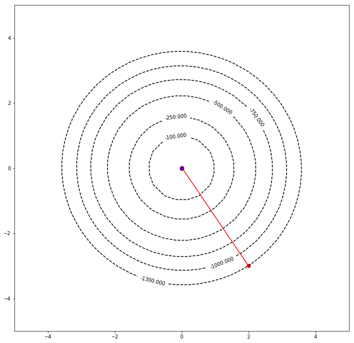

```python
level=[-1300,-1000,-750,-500,-250,-100,0,100,250,500,750,1000,1300]
q12(A,100,0.005,0.000001, lev=level,p1=5, p2=5)
```

```
A matrix:  [[1 1]
 [1 1]]
Learning Rate:  0.1

Difference in the function value(epsilon): 0.0001

Alpha: 1
C:  [[2. 1.]
 [1. 2.]]

eigenvalues:  [3. 1.]

condition num:  1.7320508075688772

Converged Iterations: 3336

Maximum of the function: [[ 1.e-323]
 [-1.e-323]]

Time taken: 0.18526172637939453

All values of x: [[ 2.00e+000 -3.00e+000]
 [ 1.80e+000 -2.20e+000]
 [ 1.52e+000 -1.68e+000]
 ...
 [ 1.48e-323 -1.48e-323]
 [ 9.88e-324 -9.88e-324]
 [ 9.88e-324 -9.88e-324]]
```

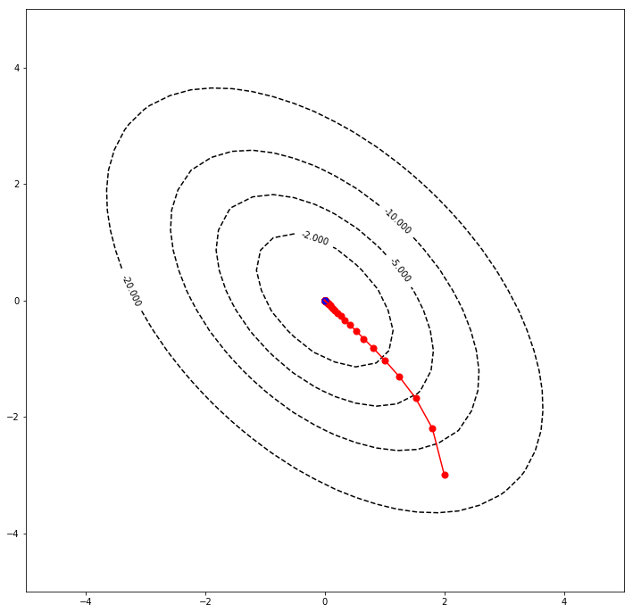

```python
level=[-20,-10,-5,-2,0,2,5,10,20]
q12(A,1,0.1,0.0001,level)
```

Also,higher condition number takes more time to converge.

##### Question 2.1

```python
def normal_distribution(R, N):
    mean_of_means = np.random.normal(size=(R,N)).mean(axis=1)
    print("Mean of means:", mean_of_means.mean())
    std = np.sqrt(mean_of_means.var())
    print("Standard deviation:",std)
    x1 = np.percentile(mean_of_means, 97.5)
    x2 = np.percentile(mean_of_means, 2.5)
    points_outside = np.logical_or(mean_of_means < x2, mean_of_means > x1)
    print("confidence interval:", x2, x1)
    print("95% Confidence Region: ", points_outside.mean())
```

```python
normal_distribution(R=1000, N=10)
```

```
Mean of means: 0.028755412421214245
Standard deviation: 0.3156331756515407
confidence interval: -0.5982592179505585 0.6526223103718204
95% Confidence Region:  0.05
```

```python
normal_distribution(R=1000,N=1000)
```

```
Mean of means: -0.0005343765417467124
Standard deviation: 0.03189837311444115
confidence interval: -0.06412983083241576 0.062326866194990116
95% Confidence Region:  0.05
```

```python
normal_distribution(R=1000,N=100000)
```

```
Mean of means: 2.108643760001999e-05
Standard deviation: 0.0032636374713416573
confidence interval: -0.00626006840750825 0.006356907868283241
95% Confidence Region:  0.05
```

##### Question 2.2

```python
pareto = np.random.pareto(a=1, size = 1000)
```

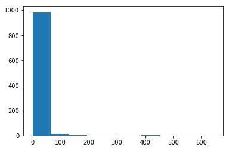

```python
plt.hist(pareto)
plt.show()
```

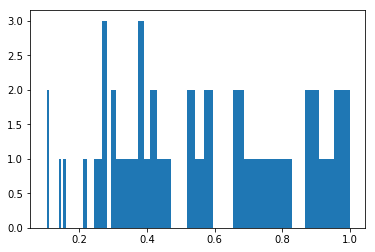

```python
pareto_100 = pareto[:100]
plt.hist(pareto_100,bins = np.logspace(np.log10(0.1),np.log10(1.0)))
plt.show()
```

```python
def pareto_distribution(R, N):
    mean_of_means = np.random.pareto(a=0.5, size=(R, N)).mean(axis=1)
    print ("mean of means: ", mean_of_means.mean())
    std = mean_of_means.std()
    print ("standard dev: ", std)
    x1 = np.percentile(mean_of_means, 97.5)
    x2 = np.percentile(mean_of_means, 2.5)

    points_outside = np.logical_or(mean_of_means < x2, mean_of_means > x1)
    print("confidence interval:", x2, x1)
    print("95% Confidence Region: ", points_outside.mean())
```

```python
pareto_distribution(1000, 1000)
```

```
mean of means:  1475939.9620126858
standard dev:  30220551.42114188
confidence interval: 376.2043144243829 568875.4266684066
95% Confidence Region:  0.05
```

```python
pareto_distribution(1000,100)
```

```
mean of means:  29493.552009666164
standard dev:  284514.00929731375
confidence interval: 33.284277154401494 130225.58357156286
95% Confidence Region:  0.05
```

```python
pareto_distribution(1000,10)
```

```
mean of means:  30776.038485923495
standard dev:  495896.57415987266
confidence interval: 2.683891737290958 22455.092652624026
95% Confidence Region:  0.05
```

Pareto distributions have higher means and standard deviations than normal distributions. For k<=1, the denominator of expected value becomes very small and expected value becomes more. The expected value for k<=1 doesn't have any significance as its value is very high and unstable unlike normal distribution as these distributions are highly skewed.